# 6372: Unit 3 Homework

Matt Farrow

## HW Instructions

The weekly HW assignments are designed to accomplish 2 goals for the MSDS student. The first is to provide a series of conceptual and analytical questions so the student can get a feel for their current understanding of the unit. The second goal is to introduce the students to standard functions and routines in R that effectively do the same things that the “Procs” do in SAS.

R and SAS are both wonderful tools and as we go through the assignments, students will begin to recognize very quickly that they both have pros and cons.

The formatting of the HW is as follows:

1. A series of high level questions will be asked with either short answers or simple multiple choice responses.
2. Analytical questions will be provided but a short vignette example of how R functions work for a given topic or method will be given. The student will then be asked a follow up question or two based on the output provided.

3.Thirdly, a new data set will be given to allow the student to gain some experience with a new data set from start to finish. This part of the homework is for your own practice and is not due at the time of HW submission.

Solutions to the HW will be provided a day or two after the HW is submitted. It is up to the student to “shore up” any confusion or misunderstanding of a topic. Grading will be based on a combination of correctness, completion, and overall conciseness.

## ANOVA Conceptual Questions

1. **State the necessary assumptions for Two-Way ANOVA analysis to be conducted. Note: Additive versus non-additive is not a component of the assumptions.**
- Residuals are normally distributed
- Constant variance
- Independent observations
2. **State in your own words what it means for there to be an “interaction” between two explanatory variables. Note: Do not explain the meaning in terms of a graph with parallel lines.**

An interaction occurs when there exists a relationship between two or more explanatory variables that affect the results.

3. **What is the familywise error rate? What is multiple testing and why is it an issue when conducting ANOVA type models such as Two-Way ANOVA?**

The familywise error rate is the probability of making at least one Type I error across all all variables in the model. Multiple testing is the process of running several tests simultaneously. The issue with multiple testing and ANOVA-type models is that the ANOVA process, by its nature, runs several tests at the same time. It is possible to have a Type I error in one part of the ANOVA testing, but not have that impact the results.

4. **True or False? The overall Type-III sums of squares F-test’s allow the analyst to determine where specific differences lie between levels of the factor.**

## Exercise #1: ACT Scores Revisited

The first step in any analysis is appropriately describing the data both numerically and visually. For a Two-Way ANOVA analysis, one of the most helpful visual tools is the mean profile plot (with or without the raw data).

The following code reads in the ACT data set from our pre-live discussion and provides a handy, modifiable function that can make a quick summary statistics table.

```r
ACT <- read.csv(here::here("6372", "week 03", "MathACT.csv"), stringsAsFactors = TRUE)

# Create a function and a summary stats table.
# Note: In line 60 below, you can add other statistics like median, IQR,etc.

mysummary <- function(x) {
  result <- c(length(x), mean(x), sd(x), sd(x) / length(x))
  names(result) <- c("N", "Mean", "SD", "SE")
  return(result)
}
sumstats <- aggregate(Score ~ Background * Sex, data = ACT, mysummary)
sumstats <- cbind(sumstats[, 1:2], sumstats[, -(1:2)])
sumstats
```

| Background | Sex | N | Mean | SD | SE |
| --- | --- | --- | --- | --- | --- |
| a | female | 82 | 9.073171 | 4.186340 | 0.05105293 |
| b | female | 387 | 13.963824 | 5.000905 | 0.01292224 |
| c | female | 54 | 24.629630 | 4.849806 | 0.08981122 |
| a | male | 48 | 11.458333 | 5.086312 | 0.10596483 |
| b | male | 223 | 15.565022 | 4.888305 | 0.02192065 |
| c | male | 67 | 25.432836 | 5.554752 | 0.08290675 |

With the three levels of background and two levels of sex status, the table provides the sample size, mean, standard deviation, and the means standard error for each of the 6 combinations of the two factors combined. This can be used to take a quick look at the data to see if things are making sense. Adding additional summaries like the max, min, and quartiles would be helpful as well.

The above table may not be too aesthetically pleasing. Luckily, under the current format of the table, it’s quite easy to generate a means profile plot to visualize the data. This graphic was most likely a major point of discussion during live session.

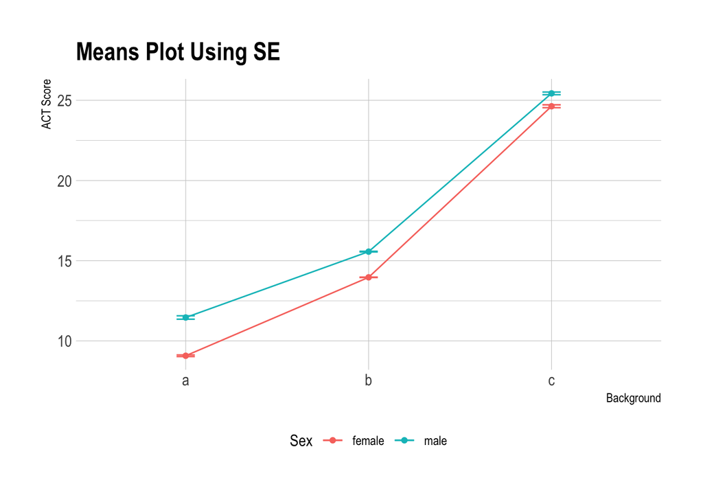

```r
ggplot(sumstats, aes(x = Background, y = Mean, group = Sex, colour = Sex)) +
  ylab("ACT Score") +
  geom_line() +
  geom_point() +
  geom_errorbar(aes(ymin = Mean - SE, ymax = Mean + SE), width = .1) +
  labs(title = "Means Plot Using SE") +
  theme_ipsum() +
  theme(legend.position = "bottom")
```

### Homework Question 1

1. **Modify the previous R script so that the summary table also includes the min, the max, and IQR. These functions are all self explanatory…min(x), max(x), IQR(x).**

```r
mysummary <- function(x) {
  result <- c(length(x), min(x), max(x), mean(x), sd(x), IQR(x), sd(x) / length(x))
  names(result) <- c("N", "Min", "Max", "Mean", "SD", "IQR", "SE")
  return(result)
}
sumstats <- aggregate(Score ~ Background * Sex, data = ACT, mysummary)
sumstats <- cbind(sumstats[, 1:2], sumstats[, -(1:2)])
sumstats
```

| Background | Sex | N | Min | Max | Mean | SD | IQR | SE |
| --- | --- | --- | --- | --- | --- | --- | --- | --- |
| a | female | 82 | 0 | 18 | 9.073171 | 4.186340 | 6.0 | 0.05105293 |
| b | female | 387 | 0 | 28 | 13.963824 | 5.000905 | 6.0 | 0.01292224 |
| c | female | 54 | 15 | 34 | 24.629630 | 4.849806 | 7.0 | 0.08981122 |
| a | male | 48 | 2 | 25 | 11.458333 | 5.086312 | 8.0 | 0.10596483 |
| b | male | 223 | 2 | 29 | 15.565022 | 4.888305 | 7.0 | 0.02192065 |
| c | male | 67 | 13 | 36 | 25.432836 | 5.554752 | 8.5 | 0.08290675 |

2. **Create another means plot but rather than using the standard errors (SE) to make the error bars. Make it with the raw standard deviations (SD). Which graphic (compared to plot using SE) is more telling about the assumption of equal variances for the ANOVA model? Give a little explanation for your answer.**

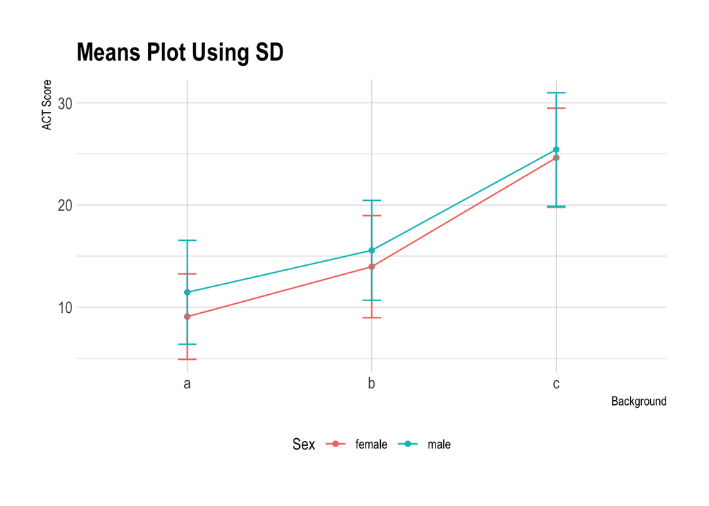

```r
ggplot(sumstats, aes(x = Background, y = Mean, group = Sex, colour = Sex)) +
  ylab("ACT Score") +
  geom_line() +
  geom_point() +
  geom_errorbar(aes(ymin = Mean - SD, ymax = Mean + SD), width = .1) +
  labs(title = "Means Plot Using SD") +
  theme_ipsum() +
  theme(legend.position = "bottom")
```

Using the standard deviation (SD) instead of the standard error (SE) allows us to assess constant variance. In looking at the error bars on the SE plot, there isn’t enough variation to plausibly say the lines are parallel, whereas the error bars on the SD plot are large enough to allow for the possibility of this being an additive model.

## Exercise #2: Conducting a Two-Way ANOVA Analysis in R

Since Two-Way ANOVA’s are technically just special cases of multiple linear regression, it’s not too surprising that the same function call is used to build the model. After viewing and exploring the data via Exercise 1 the next step would be to fit a full non-additive model, check the assumptions of the model, and then examine the type III sums of squares F-tables.

The following code fits the non-additive two-way ANOVA model and then produces the main residual diagnostics for assumption checking. Note that the syntax for including interaction terms is slightly different.

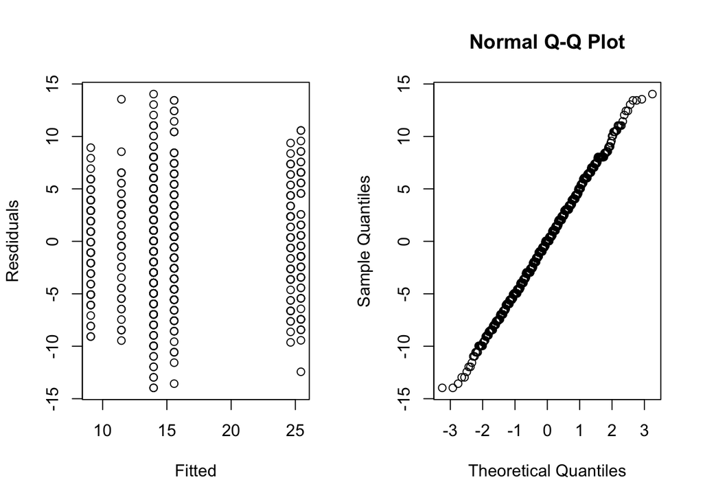

```r
model.fit <- aov(Score ~ Background + Sex + Background:Sex, data = ACT)
par(mfrow = c(1, 2))
plot(model.fit$fitted.values, model.fit$residuals, ylab = "Resdiduals", xlab = "Fitted")
qqnorm(model.fit$residuals)
```

The previous graphics are not very pretty. We can use the ggplot2 package to jazz things up a bit.

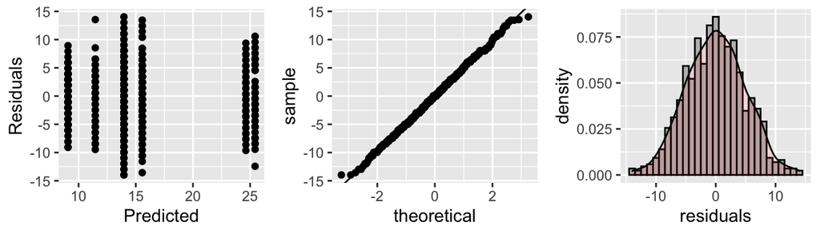

```r
library(gridExtra)
myfits <- data.frame(fitted.values = model.fit$fitted.values, residuals = model.fit$residuals)

# Residual vs Fitted
plot1 <- ggplot(myfits, aes(x = fitted.values, y = residuals)) +
  ylab("Residuals") +
  xlab("Predicted") +
  geom_point()

# QQ plot of residuals #Note the diagonal abline is only good for qqplots of normal data.
plot2 <- ggplot(myfits, aes(sample = residuals)) +
  stat_qq() +
  geom_abline(intercept = mean(myfits$residuals), slope = sd(myfits$residuals))

# Histogram of residuals
plot3 <- ggplot(myfits, aes(x = residuals)) +
  geom_histogram(aes(y = ..density..), binwidth = 1, color = "black", fill = "gray") +
  geom_density(alpha = .1, fill = "red")

grid.arrange(plot1, plot2, plot3, ncol = 3)
```

As discussed in class, the residual diagnostics do not provide any concern about the assumptions of a two-way ANOVA analysis. If there were, we would have to address those concerns via a transformation of the response or multiple analysis with and without outliers, etc. Examining the Type-III sums of squares F-table we have:

```r
library(car)
Anova(model.fit, type = 3)
```

|  | Sum Sq | Df | F value | Pr(>F) |
| --- | --- | --- | --- | --- |
| (Intercept) | 6750.43902 | 1 | 276.4609611 | 5.307325e-54 |
| Background | 8045.82134 | 2 | 164.7563583 | 3.001100e-61 |
| Sex | 172.24543 | 1 | 7.0542284 | 8.055102e-03 |
| Background:Sex | 37.64871 | 2 | 0.7709423 | 4.628982e-01 |
| Residuals | 20876.81871 | 855 | NA | NA |

Writing contrasts are a little more cumbersome in R. To help you guys out and alleviate the need to keep track of all of the zero’s and one’s, I’ve written a little script that allows you to just specify the contrast that you want in a slightly simpler way. But first let’s use some tools that provides a blanket lists of comparisons. Since there is no significant interaction, we just need to examine each factor one at a time. To examine all pairwise comparisons for “background”, the following script provides the t-test results adjusted for multiple tests using Tukey’s procedure.

```r
TukeyHSD(model.fit, "Background", conf.level = .95)
```

```
##   Tukey multiple comparisons of means
##     95% family-wise confidence level
##
## Fit: aov(formula = Score ~ Background + Sex + Background:Sex, data = ACT)
##
## $Background
##          diff       lwr       upr p adj
## b-a  4.595334  3.474636  5.716033     0
## c-a 15.120534 13.655047 16.586021     0
## c-b 10.525200  9.370655 11.679744     0
```

The table is helpful for quickly examining the results and getting the p-values and estimates. It’s always helpful to visualize.

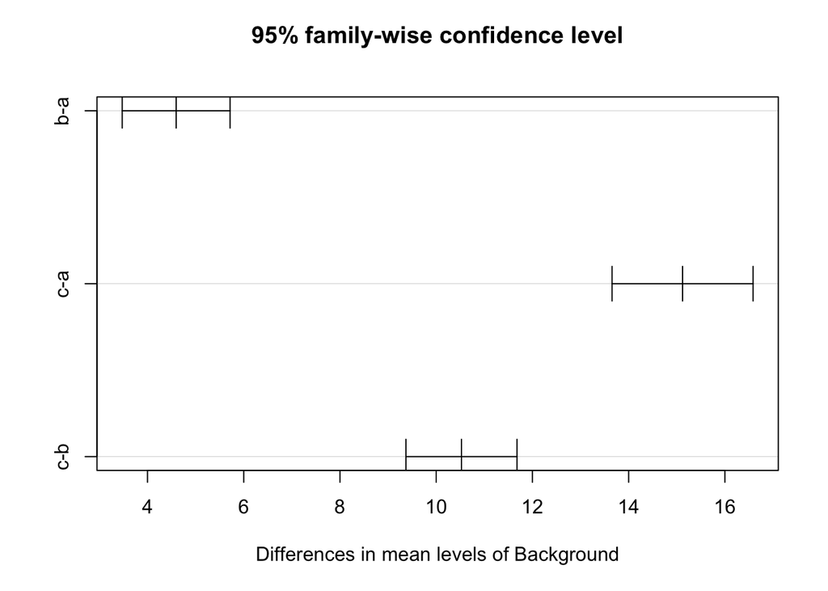

```r
plot(TukeyHSD(model.fit, "Background", conf.level = .95))
```

If an interaction is present, you can rinse and repeat the code just using the interaction term instead. This code below is for illustration; it makes no sense to do this on the ACT data set since the interaction F-test is not significant.

```r
TukeyHSD(model.fit, "Background:Sex", conf.level = .95)
```

```
##   Tukey multiple comparisons of means
##     95% family-wise confidence level
##
## Fit: aov(formula = Score ~ Background + Sex + Background:Sex, data = ACT)
##
## $`Background:Sex`
##                          diff         lwr        upr     p adj
## b:female-a:female   4.8906536   3.1748785   6.606429 0.0000000
## c:female-a:female  15.5564589  13.0830154  18.029902 0.0000000
## a:male-a:female     2.3851626  -0.1797967   4.950122 0.0854058
## b:male-a:female     6.4918517   4.6691025   8.314601 0.0000000
## c:male-a:female    16.3596651  14.0354027  18.683927 0.0000000
## c:female-b:female  10.6658053   8.6155720  12.716039 0.0000000
## a:male-b:female    -2.5054910  -4.6652479  -0.345734 0.0123022
## b:male-b:female     1.6011981   0.4146282   2.787768 0.0017335
## c:male-b:female    11.4690115   9.6014652  13.336558 0.0000000
## a:male-c:female   -13.1712963 -15.9710443 -10.371548 0.0000000
## b:male-c:female    -9.0646072 -11.2051648  -6.924050 0.0000000
## c:male-c:female     0.8032062  -1.7778339   3.384246 0.9492008
## b:male-a:male       4.1066891   1.8610087   6.352369 0.0000033
## c:male-a:male      13.9745025  11.3056335  16.643371 0.0000000
## c:male-b:male       9.8678134   7.9015327  11.834094 0.0000000
```

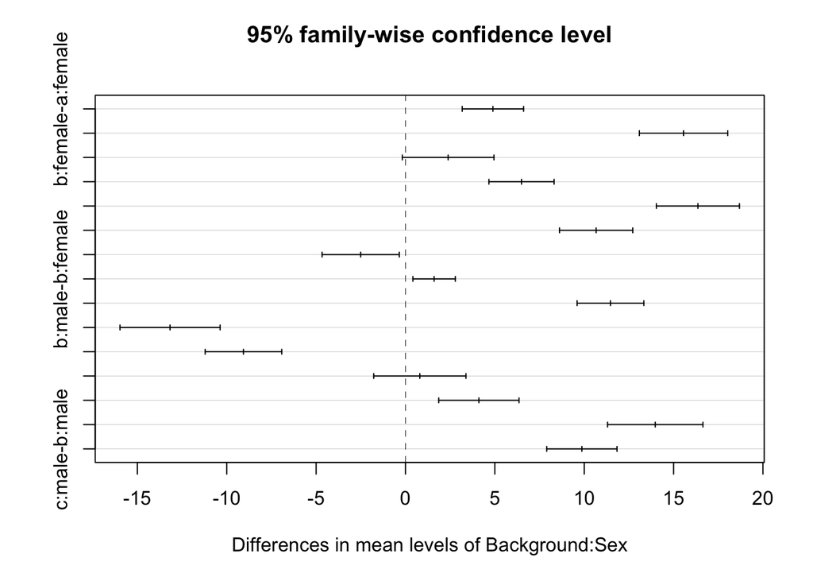

```r
plot(TukeyHSD(model.fit, "Background:Sex", conf.level = .95))
```

As discussed in class, including all possible combinations of comparisons may be too much, and of little interest, to the actual study at hand. We can manually create the comparisons of interest and manually adjust the p-values through writing contrasts. To help streamline this for you, I’ve included a little R script that makes the process more automated for you.

The following script allow you to write out your contrasts in a more verbal syntax. I’ll run you through the most tedious scenario. The script can be easily modified to handle simpler situations. First things first, all you need to do is provide some details as to what comparisons you’d like to make. Suppose, that if the interaction was significant, the only meaningful comparisons to make in the analysis comparing males versus females for each level of background.

```r
library(emmeans)
contrast.factor <- ~ Background * Sex
mycontrast <- c("amale-afemale", "bmale-bfemale", "cmale-cfemale")
dat <- ACT
```

The above piece of code provides no output, but formats things for the following code to run. The key player here is the `contrast.factor` and the `mycontrast` objects. The `contrast.factor` piece is just specifying what types of comparisons you would like to make. For example, if we only wanted to compare the background levels we would have just specified `~Background`. The `mycontrast` object is where you get to specify what comparisons you would like to make. For a single factor, you just simply write out the factor levels you want to compare with a subtraction between them. For an interaction type comparison the syntax depends on what was used in the `contrast.factor` object. In our example, background is listed first, so when making comparisons the levels of background are concatenated to the levels of Sex before subtracting which combinations you want to compare.

The following code is something I wrote that takes the information you specified above and creates a clean table of results with Bonferroni adjusted p-values. This script can be reused over and over, just changing the initial starting script is all that is required.

```r
# Running a loop that determines the appropriate 0's and 1's for each contrast
# specified above.
library(limma)
final.result <- c()
for (j in 1:length(mycontrast)) {
  contrast.factor.names <-
    gsub(" ", "", unlist(strsplit(
      as.character(contrast.factor),
      split = "*",
      fixed = T
    ))[-1])
  contrast.factor.2 <- vector("list", length(contrast.factor.names))
  for (i in 1:length(contrast.factor.names)) {
    contrast.factor.2[[i]] <- levels(dat[, contrast.factor.names[i]])
  }
  new.factor.levels <- do.call(paste, c(do.call(
    expand.grid,
    contrast.factor.2
  ), sep = ""))
  temp.cont <- mycontrast[j]

  contrast2 <- list(comparison = as.vector(do.call(
    makeContrasts,
    list(contrasts = temp.cont, levels = new.factor.levels)
  )))

  contrast.result <- summary(contrast(lsmeans(
    model.fit,
    contrast.factor
  ), contrast2, by = NULL))

  final.result <- rbind(final.result, contrast.result)
}

# Cleaning up and applying Bonferroni correction to the number of total
# comparisons investigated.
final.result$contrast <- mycontrast
final.result$bonf <- length(mycontrast) * final.result$p.value
final.result$bonf[final.result$bonf > 1] <- 1

# Print final result
final.result
```

| contrast | estimate | SE | df | t.ratio | p.value | bonf |
| --- | --- | --- | --- | --- | --- | --- |
| amale-afemale | 2.3851626 | 0.8980349 | 855 | 2.6559797 | 0.0080551020 | 0.0241653060 |
| bmale-bfemale | 1.6011981 | 0.4154379 | 855 | 3.8542419 | 0.0001247819 | 0.0003743458 |
| cmale-cfemale | 0.8032062 | 0.9036651 | 855 | 0.8888317 | 0.3743435212 | 1.0000000000 |

### Homework Question 2

**Consider comparing the mean ACT scores of males versus females specifically for background A. Compare the outputs from the Tukey comparison result table to that of the output generated from my manual contrast maker. Are the estimated differences the same? Can you explain why the adjusted p-values are different for the two result tables? One would suggest that we reject the null while the other would have us to fail to reject. (This is just a conceptual thinking question. The interaction term is not significant for this data analysis.)**

## Exercise #3

Let’s examine the dta Exercise 13.17 from the statistical sleuth book. The data set is easily accesable in R via the following package.

```r
library(Sleuth3)
head(ex1317)
```

|  | Iridium | Strata | DepthCat |
| --- | --- | --- | --- |
| 1 | 75 | Limestone | 1 |
| 2 | 200 | Limestone | 1 |
| 3 | 120 | Limestone | 2 |
| 4 | 310 | Limestone | 2 |
| 5 | 290 | Limestone | 3 |
| 6 | 450 | Limestone | 3 |

1. **Provide a means plot of the data. Use this, along with any additional information, to comment on whether an additive or non-additive model is most appropriate.**

```r
# Store data
iridium <- ex1317

# Log transform iridium
iridium <- iridium %>%
  mutate(log_iridium = log(Iridium))

# Look at data
head(iridium)
```

|  | Iridium | Strata | DepthCat | log_iridium |
| --- | --- | --- | --- | --- |
| 1 | 75 | Limestone | 1 | 4.317488 |
| 2 | 200 | Limestone | 1 | 5.298317 |
| 3 | 120 | Limestone | 2 | 4.787492 |
| 4 | 310 | Limestone | 2 | 5.736572 |
| 5 | 290 | Limestone | 3 | 5.669881 |
| 6 | 450 | Limestone | 3 | 6.109248 |

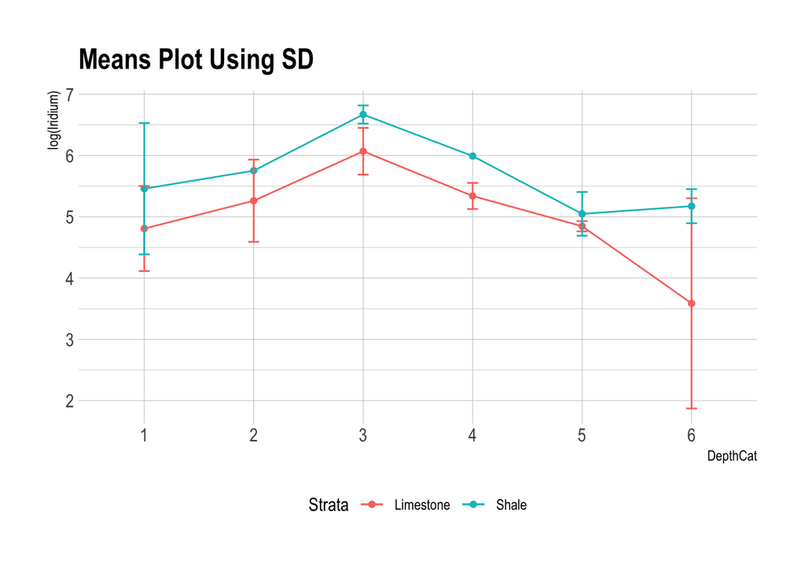

```r
# Create summary statistics
mysummary <- function(x) {
  result <- c(length(x), min(x), max(x), mean(x), sd(x), IQR(x), sd(x) / length(x))
  names(result) <- c("N", "Min", "Max", "Mean", "SD", "IQR", "SE")
  return(result)
}
iridium_stats <- aggregate(log_iridium ~ DepthCat * Strata, data = iridium, mysummary)
iridium_stats <- cbind(iridium_stats[, 1:2], iridium_stats[, -(1:2)])

# Create means plot
iridium_stats %>%
  ggplot(aes(
    x = DepthCat,
    y = Mean,
    group = Strata,
    colour = Strata
  )) +
  geom_line() +
  geom_point() +
  geom_errorbar(aes(ymin = Mean - SD, ymax = Mean + SD), width = .1) +
  labs(title = "Means Plot Using SD",
       y = "log(Iridium)") +
  theme_ipsum() +
  theme(legend.position = "bottom")
```

I first ran this plot using the raw data and the lines were all over the place. I ran it again, this time log-transforming the Iridium count. Although the error bars show promise of overlap, at DepthCat 3 and 4, there is still no overlap. It appears this is a non-additive model.

2. **Fit a non-additive two-way ANOVA model to the data set and provide the residual diagnostics. Comment on the appropriateness of the current ANOVA fit.**

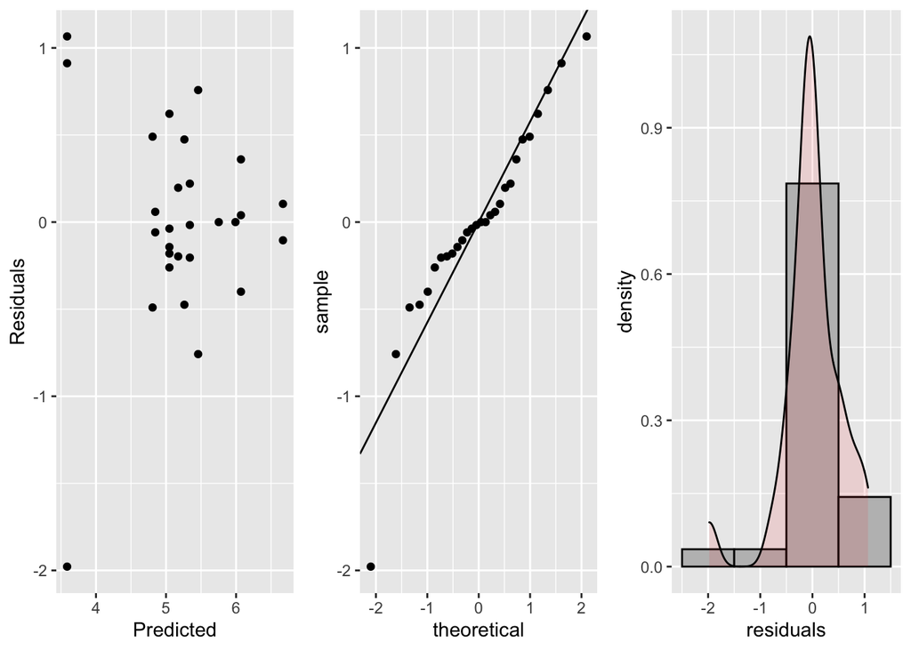

```r
# Build model
model_fit <- aov(log_iridium ~ DepthCat + Strata + DepthCat:Strata, data = iridium)

# Create fits
model_fit2 <- tibble(fitted_values = model_fit$fitted.values,
                    residuals = model_fit$residuals)

# Residual vs Fitted
plot1 <- ggplot(model_fit2, aes(x = fitted_values, y = residuals)) +
  ylab("Residuals") +
  xlab("Predicted") +
  geom_point()

# QQ plot of residuals #Note the diagonal abline is only good for qqplots of normal data.
plot2 <- ggplot(model_fit2, aes(sample = residuals)) +
  stat_qq() +
  geom_abline(
    intercept = mean(model_fit2$residuals),
    slope = sd(model_fit2$residuals)
  )

# Histogram of residuals
plot3 <- ggplot(model_fit2, aes(x = residuals)) +
  geom_histogram(
    aes(y = ..density..),
    binwidth = 1,
    color = "black",
    fill = "gray"
  ) +
  geom_density(alpha = .1, fill = "red")

# Arrange plots
grid.arrange(plot1, plot2, plot3, ncol = 3)
```

In the first plot, the residuals appear to be fairly randomly distributed using the log-transformed Iridium counts. The Q-Q plot does show some deviations from normality towards the left side of the plot, although it is difficult to tell if this is simply due to the small sample size. The histogram of residuals also shows a slight bump around -2 on the x-axix, which combined with the three outliers on the first plot and the slight deviation from normality in the second plot give me pause. I’m not sure however what else to do at this point and will proceed with the transformation that I’ve made so far.

3. **Provide the Type-III ANOVA F-tests. Answer the following question using the table. Do the potential changes in mean Iridium by strata depend on the depth?**

```r
Anova(model_fit, type = 3)
```

|  | Sum Sq | Df | F value | Pr(>F) |
| --- | --- | --- | --- | --- |
| (Intercept) | 46.2318575 | 1 | 82.5560725 | 0.0000001024445 |
| DepthCat | 10.0184171 | 5 | 3.5779708 | 0.0231286687944 |
| Strata | 0.4233331 | 1 | 0.7559444 | 0.3974565939721 |
| DepthCat:Strata | 1.3418954 | 5 | 0.4792436 | 0.7865781257404 |
| Residuals | 8.9600886 | 16 | NA | NA |

Based on the ANOVA table, it doesn’t appear that the interaction between DepthCat and Strata is significant (p-value = 0.78658). The only significant result was DepthCat (p-value 0.02313).

4. **Using multiple testing techniques, determine what factors (or combinations) contribute to changes in mean iridium.**

```r
TukeyHSD(model_fit, "DepthCat", conf.level = .95)
```

```
##   Tukey multiple comparisons of means
##     95% family-wise confidence level
##
## Fit: aov(formula = log_iridium ~ DepthCat + Strata + DepthCat:Strata, data = iridium)
##
## $DepthCat
##            diff        lwr         upr     p adj
## 2-1  0.29232257 -1.5492989  2.13394406 0.9949491
## 3-1  1.17644438 -0.4410703  2.79395907 0.2334292
## 4-1  0.36951566 -1.3354945  2.07452585 0.9794746
## 5-1 -0.14271103 -1.6540410  1.36861897 0.9995759
## 6-1 -0.91110705 -2.5286217  0.70640764 0.4839724
## 3-2  0.88412181 -0.8768051  2.64504876 0.5994114
## 4-2  0.07719309 -1.7644284  1.91881457 0.9999923
## 5-2 -0.43503360 -2.0989532  1.22888596 0.9547180
## 6-2 -1.20342962 -2.9643566  0.55749733 0.2892658
## 4-3 -0.80692872 -2.4244434  0.81058597 0.6055595
## 5-3 -1.31915541 -2.7310380  0.09272716 0.0742667
## 6-3 -2.08755143 -3.6125589 -0.56254396 0.0048473
## 5-4 -0.51222669 -2.0235567  0.99910331 0.8775240
## 6-4 -1.28062271 -2.8981374  0.33689198 0.1669346
## 6-5 -0.76839602 -2.1802786  0.64348655 0.5192621
```

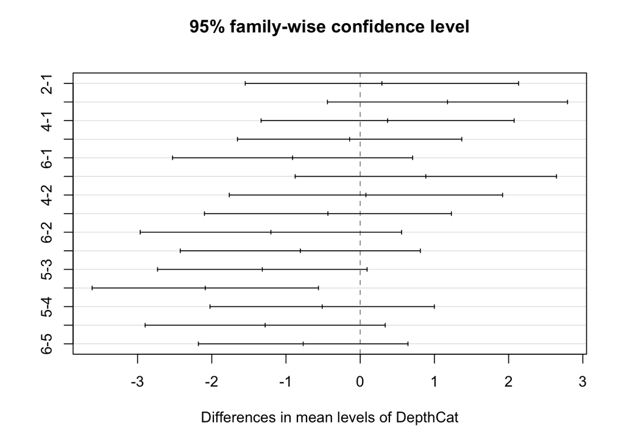

```r
plot(TukeyHSD(model_fit, "DepthCat", conf.level = .95))
```

```r
contrast.factor <- ~ Strata * DepthCat
mycontrast <- c(6-3)

dat <- iridium

final.result <- c()

for (j in 1:length(mycontrast)) {
  contrast.factor.names <-
    gsub(" ", "", unlist(strsplit(
      as.character(contrast.factor),
      split = "*",
      fixed = T
    ))[-1])
  contrast.factor.2 <- vector("list", length(contrast.factor.names))
  for (i in 1:length(contrast.factor.names)) {
    contrast.factor.2[[i]] <- levels(dat[, contrast.factor.names[i]])
  }
  new.factor.levels <- do.call(paste, c(do.call(
    expand.grid,
    contrast.factor.2
  ), sep = ""))
  temp.cont <- mycontrast[j]

  contrast2 <- list(comparison = as.vector(do.call(
    makeContrasts,
    list(contrasts = temp.cont, levels = new.factor.levels)
  )))

  contrast.result <- summary(contrast(lsmeans(
    model_fit,
    contrast.factor
  ), contrast2, by = NULL))

  final.result <- rbind(final.result, contrast.result)
}

# Cleaning up and applying Bonferroni correction to the number of total
# comparisons investigated.
final.result$contrast <- mycontrast
final.result$bonf <- length(mycontrast) * final.result$p.value
final.result$bonf[final.result$bonf > 1] <- 1

# Print final result
final.result
```

| contrast | estimate | SE | df | t.ratio | p.value | bonf |
| --- | --- | --- | --- | --- | --- | --- |
| 3 | 192.023 | 5.590019 | 16 | 34.35105 | 0.0000000000000002026853 | 0.0000000000000002026853 |